# Biostat 203B Homework 2

Due Feb 7 @ 11:59PM

Rui Xu

Use tidyverse (ggpot2, dplyr) to explore the [MIMIC-III](https://mimic.physionet.org) data introduced in [homework 1](https://ucla-biostat203b-2020winter.github.io/hw/hw1/hw1.html).

## Q1

Demographic information of the patients admitted into hospital is available in `ADMISSION.csv`. See https://mimic.physionet.org/mimictables/admissions/ for details of each field in this file. Summarize following variables using appropriate graphs:

- admission year
- admission month
- admission week day
- admission hour
- length of hospital stay
- admission type
- number of admissions per patient
- admission location
- insurance
- language
- religion
- martial status
- ethnicity
- death

Note it is possible that one patient (uniquely identified by the `SUBJECT_ID`) is admitted into hospital multiple times. When summarizing some demographic information, it makes sense to summarize based on only unique patients.

**solution:**

### Prerequisites

Load tidyverse and lubridate:

```r
    library(tidyverse)
    library(lubridate)
```

### Import data

Let’s turn flat files into tibble:

```r
    admission <- read_csv("/home/203bdata/mimic-iii/ADMISSIONS.csv",
                     col_types = cols(ROW_ID = col_integer(),
                                      SUBJECT_ID = col_integer(),
                                      HADM_ID = col_integer(),
                                      HOSPITAL_EXPIRE_FLAG = col_logical(),
                                      HAS_CHARTEVENTS_DATA = col_logical()))
    admission %>% print(width = Inf)
```

```
## # A tibble: 58,976 x 19
##    ROW_ID SUBJECT_ID HADM_ID ADMITTIME           DISCHTIME
##     <int>      <int>   <int> <dttm>              <dttm>
##  1     21         22  165315 2196-04-09 12:26:00 2196-04-10 15:54:00
##  2     22         23  152223 2153-09-03 07:15:00 2153-09-08 19:10:00
##  3     23         23  124321 2157-10-18 19:34:00 2157-10-25 14:00:00
##  4     24         24  161859 2139-06-06 16:14:00 2139-06-09 12:48:00
##  5     25         25  129635 2160-11-02 02:06:00 2160-11-05 14:55:00
##  6     26         26  197661 2126-05-06 15:16:00 2126-05-13 15:00:00
##  7     27         27  134931 2191-11-30 22:16:00 2191-12-03 14:45:00
##  8     28         28  162569 2177-09-01 07:15:00 2177-09-06 16:00:00
##  9     29         30  104557 2172-10-14 14:17:00 2172-10-19 14:37:00
## 10     30         31  128652 2108-08-22 23:27:00 2108-08-30 15:00:00
##    DEATHTIME           ADMISSION_TYPE ADMISSION_LOCATION
##    <dttm>              <chr>          <chr>
```

[output cut: 59 more lines]

### Graphs

#### admission year

Based on each admission record, the admission year is treated as a continuous variable. In general, the amount of patients admitted every year does not have much difference.

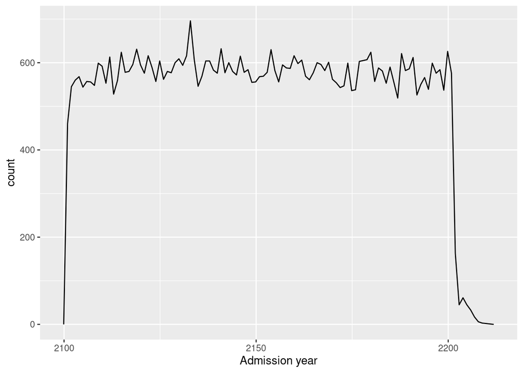

```r
    admission %>%
      ggplot(aes(x = ADMITTIME)) +
      geom_freqpoly(binwidth = 31536000) + # 86400 seconds = 1 day
      labs(x = "Admission year")
```

#### admission month

Based on each admission record, the admission month is treated as a discrete variable. In general, the amount of patients admitted every month does not have much difference.

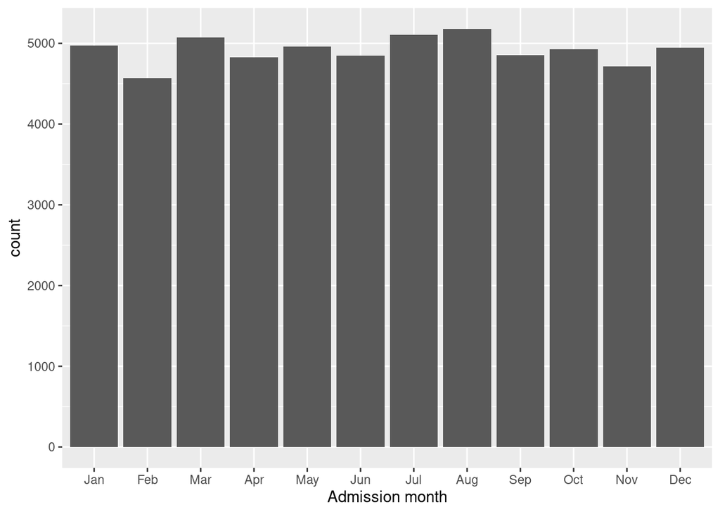

```r
    admission %>%
      mutate(adm_month = month(ADMITTIME, label = TRUE)) %>%
      ggplot(aes(x = adm_month)) +
      geom_bar() +
      labs(x = "Admission month")
```

#### admission weekday

Based on each admission record, the admission weekday is treated as a discrete variable. In general, the hospital is busier during workday than during weekend.

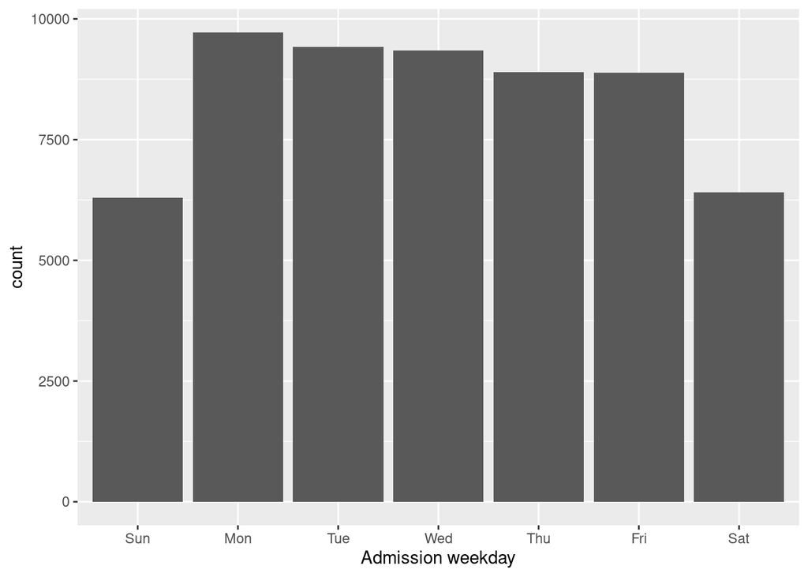

```r
    admission %>%
      mutate(adm_wday = wday(ADMITTIME, label = TRUE)) %>%
      ggplot(aes(x = adm_wday)) +
      geom_bar() +
      labs(x = "Admission weekday")
```

#### admission hour

Based on each admission record, the admission hour is treated as a discrete variable. In general, the admission hour has a peak value around 7 am and the hosiptal is busier during afternoon.

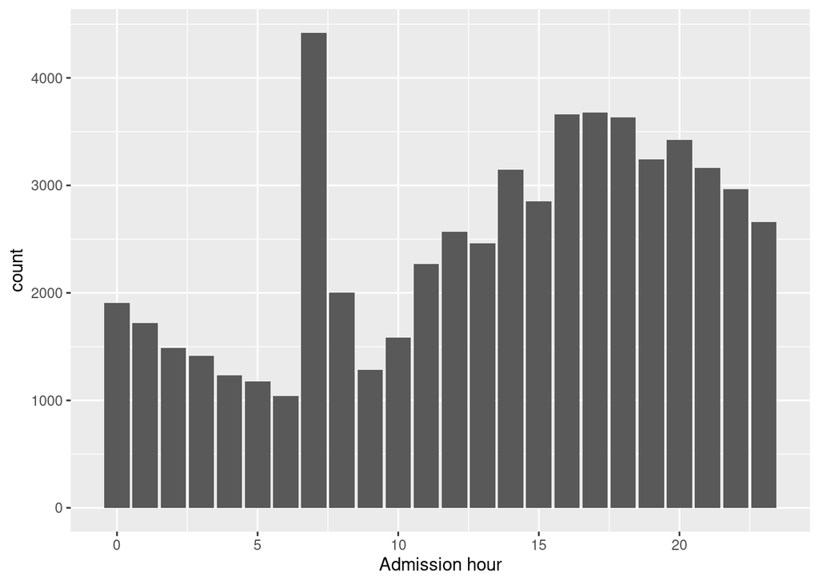

```r
    admission %>%
      mutate(adm_hour = hour(ADMITTIME)) %>%
      ggplot(aes(x = adm_hour)) +
      geom_bar() +
      labs(x = "Admission hour")
```

#### length of hospital stay

Based on each admission record, the length of hospital stay is treated as a discrete variable. In general, most of the patients stay in the hospital less than 25 days.

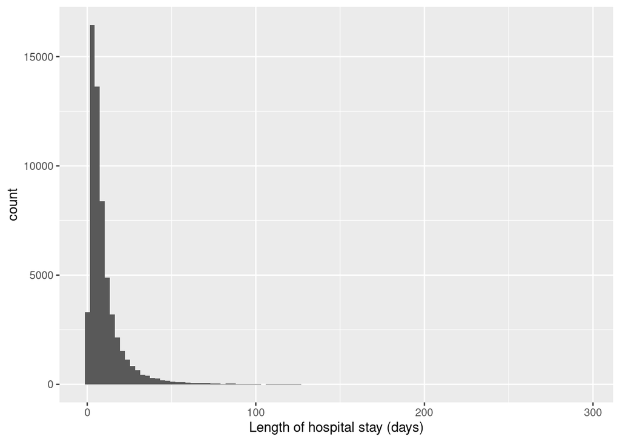

```r
    admission %>%
      mutate(los_days = as.numeric(as.duration(DISCHTIME - ADMITTIME)
                                 / 86400)) %>%
      ggplot(aes(x = los_days)) +
      geom_histogram(bins = 100) +
      labs(x = "Length of hospital stay (days)")
```

#### admission type

Based on each admission record, the admission type is treated as a discrete variable. The most admission type is emergency and the least admission type is urgent.

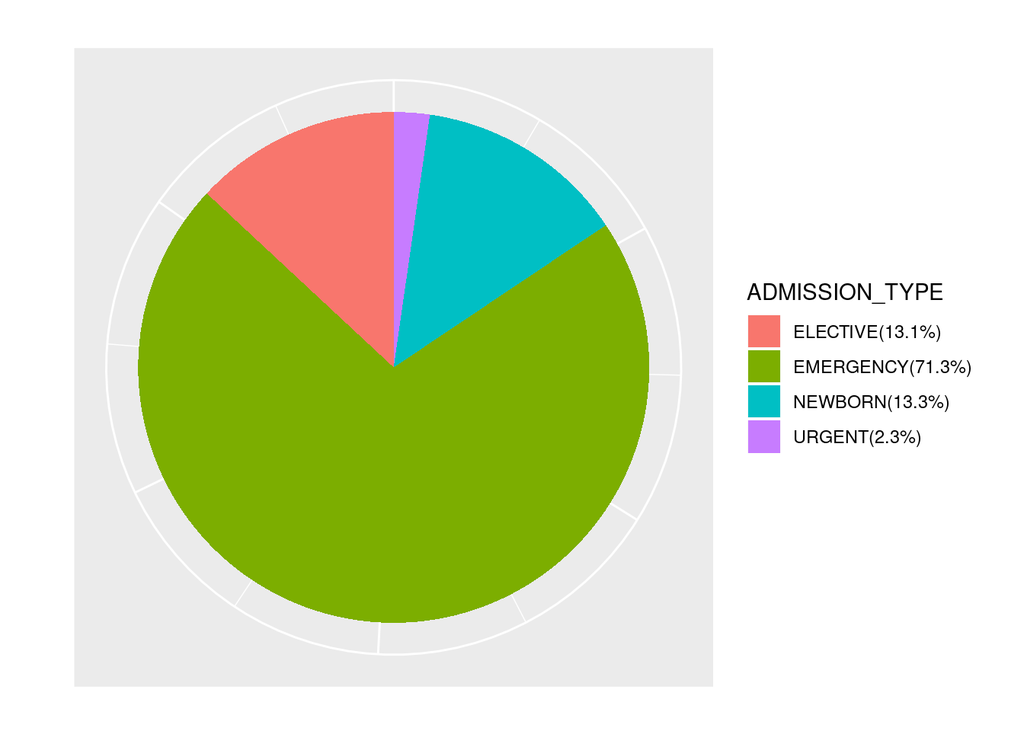

```r
    adm_type <- admission %>%
      group_by(ADMISSION_TYPE) %>%
      summarise(
        count = n()
      ) %>% as.data.frame
    label_value <- paste('(', round(adm_type$count / sum(adm_type$count) * 100,
                                    1), '%)', sep = '')
    label <- paste(adm_type$ADMISSION_TYPE, label_value, sep = '')
    admission %>%
      ggplot(mapping = aes(x = 'portion', fill = ADMISSION_TYPE)) +
      geom_bar(width = 1) +
      coord_polar("y") +
      labs(x = '', y = '', title = '') +
      theme(axis.text = element_blank()) +
      theme(axis.ticks = element_blank()) +
      scale_fill_discrete(labels = label)
```

#### number of admissions per patient

Based on each unique patient, the number of admissions per patient is treated as a discrete variable. Most of the patients are only admitted to the hospital once.

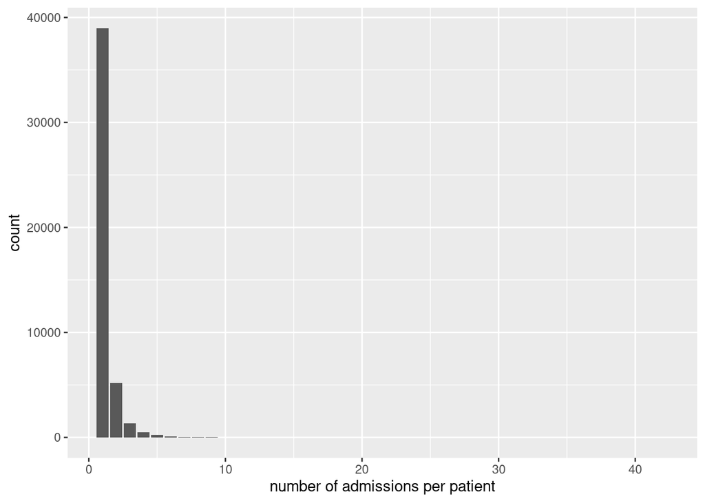

```r
    adm_num <- admission %>%
       group_by(SUBJECT_ID) %>%
       summarise(
         count = n()
       )
    adm_num %>%
      ggplot(aes(x = count)) +
      geom_bar() +
      labs(x = "number of admissions per patient")
```

#### admission location

Based on each admission record, the admission location is treated as a discrete variable. The most admission location is emergency room admit, which corresponds to the most admission type.

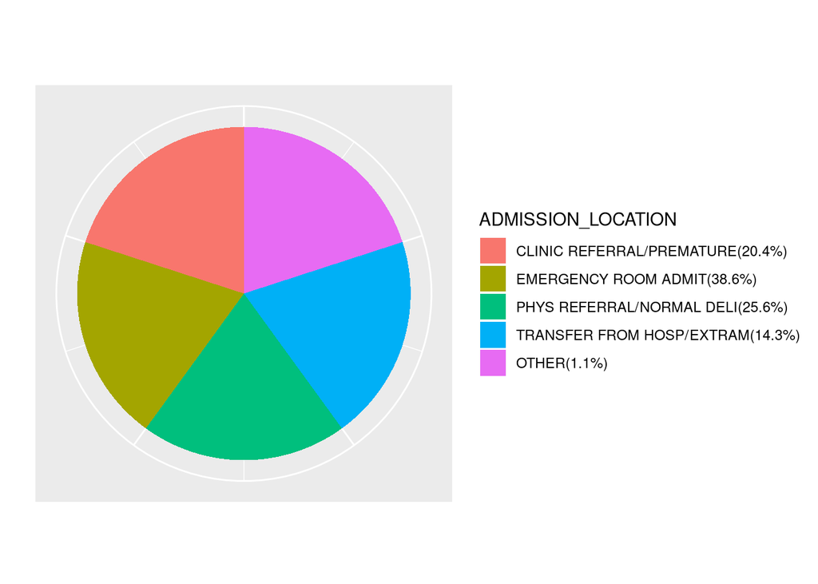

```r
    adm_loc1 <- admission %>%
      group_by(ADMISSION_LOCATION) %>%
      summarise(
        count = n()
      ) %>%
      filter(count > 600)
    adm_loc2 <- admission %>%
      group_by(ADMISSION_LOCATION) %>%
      summarise(count = n()) %>%
      filter(count <= 600) %>%
      mutate(tmp = sum(count))
    adm_loc3 <- tribble(~ADMISSION_LOCATION, ~count,
                        "OTHER", adm_loc2$tmp[1])
    adm_loc <- bind_rows(adm_loc1, adm_loc3) %>% as.data.frame
    label_value <- paste('(', round(adm_loc$count / sum(adm_loc$count) * 100,
                                    1), '%)', sep = '')
    label <- paste(adm_loc$ADMISSION_LOCATION, label_value, sep = '')
    adm_loc %>%
      ggplot(mapping = aes(x = 'portion', fill = ADMISSION_LOCATION)) +
      geom_bar(width = 1) +
      coord_polar("y") +
      labs(x = '', y = '', title = '') +
      theme(axis.text = element_blank()) +
      theme(axis.ticks = element_blank()) +
      scale_fill_discrete(labels = label)
```

#### insurance

Based on each unique patient, we can get a sense of the insurance distribution. The insurance is treated as a discrete variable. Most of the patients use medicare and least of the patients pay by themselves.

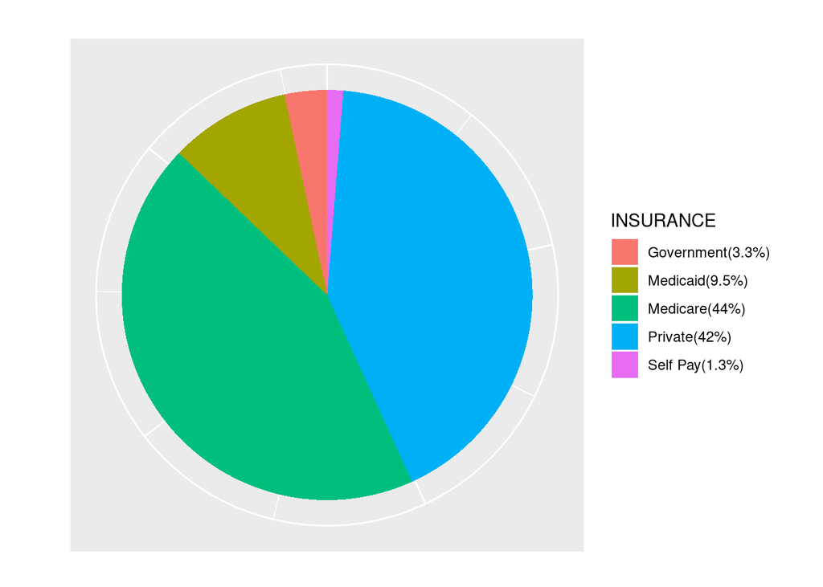

```r
    people <- distinct(admission, SUBJECT_ID, .keep_all = TRUE)
    insurance <- people %>%
      group_by(INSURANCE) %>%
      summarise(
        count = n()
      ) %>% as.data.frame
    label_value <- paste('(', round(insurance$count / sum(insurance$count)
                                    * 100, 1), '%)', sep = '')
    label <- paste(insurance$INSURANCE, label_value, sep = '')
    people %>%
      ggplot(mapping = aes(x = 'portion', fill = INSURANCE)) +
      geom_bar(width = 1) +
      coord_polar("y") +
      labs(x = '', y = '', title = '') +
      theme(axis.text = element_blank()) +
      theme(axis.ticks = element_blank()) +
      scale_fill_discrete(labels = label)
```

#### language

Based on each unique patient, we can get a sense of the language distribution. The language is treated as a discrete variable. Most of the patients speak English.

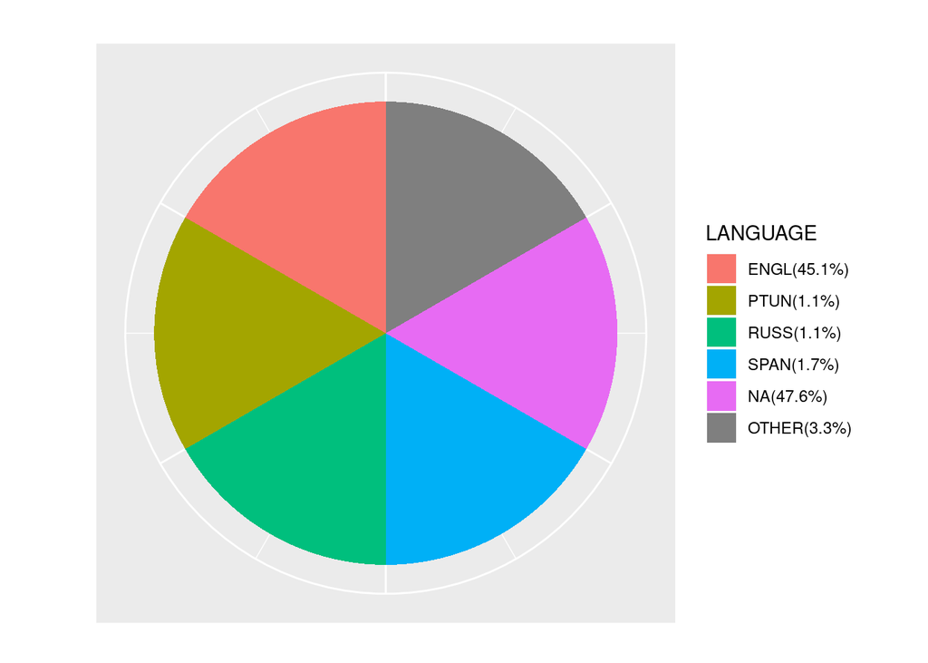

```r
    people <- distinct(admission, SUBJECT_ID, .keep_all = TRUE)
    language1 <- people %>%
      group_by(LANGUAGE) %>%
      summarise(
        count = n()
      ) %>%
      filter(count > 460)
    language2 <- people %>%
      group_by(LANGUAGE) %>%
      summarise(count = n()) %>%
      filter(count <= 460) %>%
      mutate(tmp = sum(count))
    language3 <- tribble(~LANGUAGE, ~count,
                        "OTHER", language2$tmp[1])
    language <- bind_rows(language1, language3) %>% as.data.frame
    label_value <- paste('(', round(language$count / sum(language$count)
                                    * 100, 1), '%)', sep = '')
    label <- paste(language$LANGUAGE, label_value, sep = '')
    language %>%
      ggplot(mapping = aes(x = 'portion', fill = LANGUAGE)) +
      geom_bar(width = 1) +
      coord_polar("y") +
      labs(x = '', y = '', title = '') +
      theme(axis.text = element_blank()) +
      theme(axis.ticks = element_blank()) +
      scale_fill_discrete(labels = label)
```

#### religion

Based on each unique patient, we can get a sense of the religion distribution. The religion is treated as a discrete variable. Most of the patients are catholic.

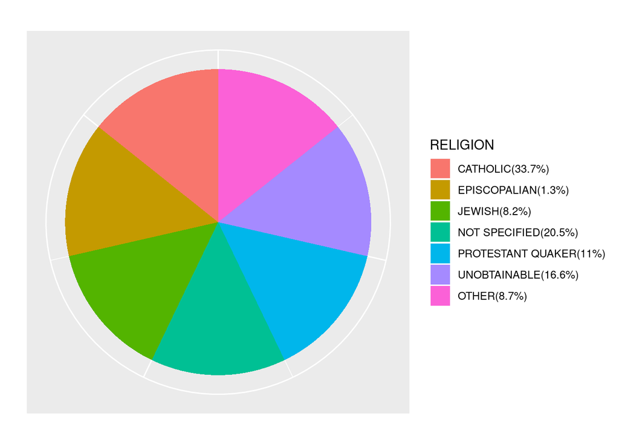

```r
    people <- distinct(admission, SUBJECT_ID, .keep_all = TRUE)
    religion1 <- people %>%
      group_by(RELIGION) %>%
      summarise(
        count = n()
      ) %>%
      filter(count > 460, RELIGION != "OTHER")
    religion2 <- people %>%
      group_by(RELIGION) %>%
      summarise(count = n()) %>%
      filter(count <= 460 | RELIGION == "OTHER") %>%
      mutate(tmp = sum(count))
    religion3 <- tribble(~RELIGION, ~count,
                        "OTHER", religion2$tmp[1])
    religion <- bind_rows(religion1, religion3) %>% as.data.frame
    label_value <- paste('(', round(religion$count / sum(religion$count)
                                    * 100, 1), '%)', sep = '')
    label <- paste(religion$RELIGION, label_value, sep = '')
    religion %>%
      ggplot(mapping = aes(x = 'portion', fill = RELIGION)) +
      geom_bar(width = 1) +
      coord_polar("y") +
      labs(x = '', y = '', title = '') +
      theme(axis.text = element_blank()) +
      theme(axis.ticks = element_blank()) +
      scale_fill_discrete(labels = label)
```

#### martial status

Based on each unique patient, we can get a sense of the martial status distribution. The martial status is treated as a discrete variable. Most of the patients are married.

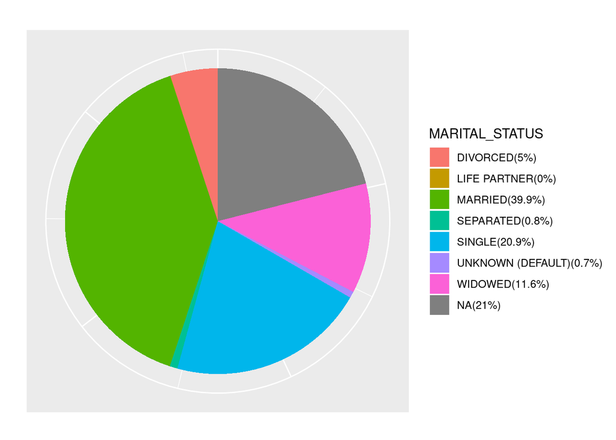

```r
    people <- distinct(admission, SUBJECT_ID, .keep_all = TRUE)
    martst <- people %>%
      group_by(MARITAL_STATUS) %>%
      summarise(
        count = n()
      ) %>% as.data.frame
    label_value <- paste('(', round(martst$count / sum(martst$count)
                                    * 100, 1), '%)', sep = '')
    label <- paste(martst$MARITAL_STATUS, label_value, sep = '')
    people %>%
      ggplot(mapping = aes(x = 'portion', fill = MARITAL_STATUS)) +
      geom_bar(width = 1) +
      coord_polar("y") +
      labs(x = '', y = '', title = '') +
      theme(axis.text = element_blank()) +
      theme(axis.ticks = element_blank()) +
      scale_fill_discrete(labels = label)
```

#### ethnicity

Based on each unique patient, we can get a sense of the ethnicity distribution. The ethnicity is treated as a discrete variable. Most of the patients are white.

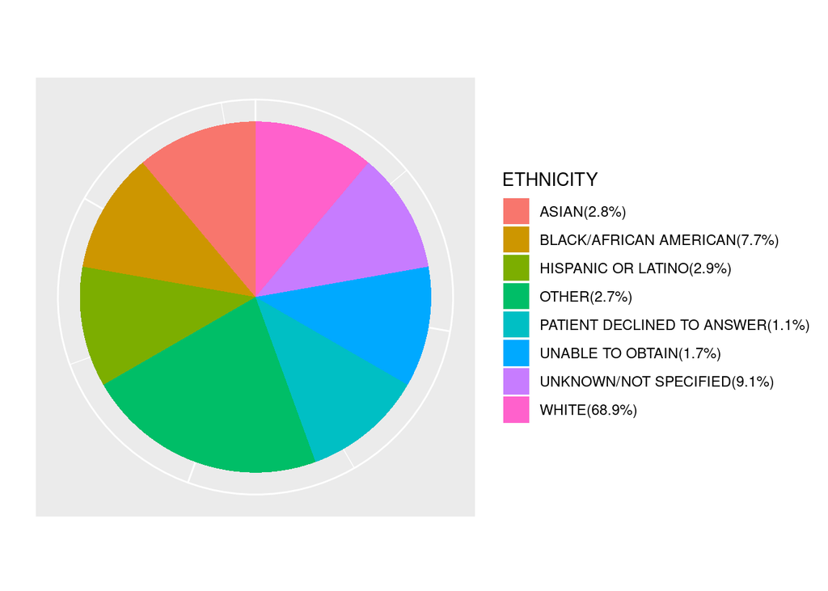

```r
    people <- distinct(admission, SUBJECT_ID, .keep_all = TRUE)
    enth1 <- people %>%
      group_by(ETHNICITY) %>%
      summarise(
        count = n()
      ) %>%
      filter(count > 460)
    enth2 <- people %>%
      group_by(ETHNICITY) %>%
      summarise(count = n()) %>%
      filter(count <= 460) %>%
      mutate(tmp = sum(count))
    enth3 <- tribble(~ETHNICITY, ~count,
                        "OTHER", enth2$tmp[1])
    enth <- bind_rows(enth1, enth3) %>% as.data.frame
    label_value <- paste('(', round(enth$count / sum(enth$count)
                                    * 100, 1), '%)', sep = '')
    label <- paste(enth$ETHNICITY, label_value, sep = '')
    enth %>%
      ggplot(mapping = aes(x = 'portion', fill = ETHNICITY)) +
      geom_bar(width = 1) +
      coord_polar("y") +
      labs(x = '', y = '', title = '') +
      theme(axis.text = element_blank()) +
      theme(axis.ticks = element_blank()) +
      scale_fill_discrete(labels = label)
```

#### death

Since the death analysis for each admission makes more sense than the death analysis for each person from the perspective of each illness condition, the death analysis is based on each admission record. After plotting the death time with respect to the year, month, weekday and hour, we can conclude that the death happens randomly everyday but most of the death happens in the noon.

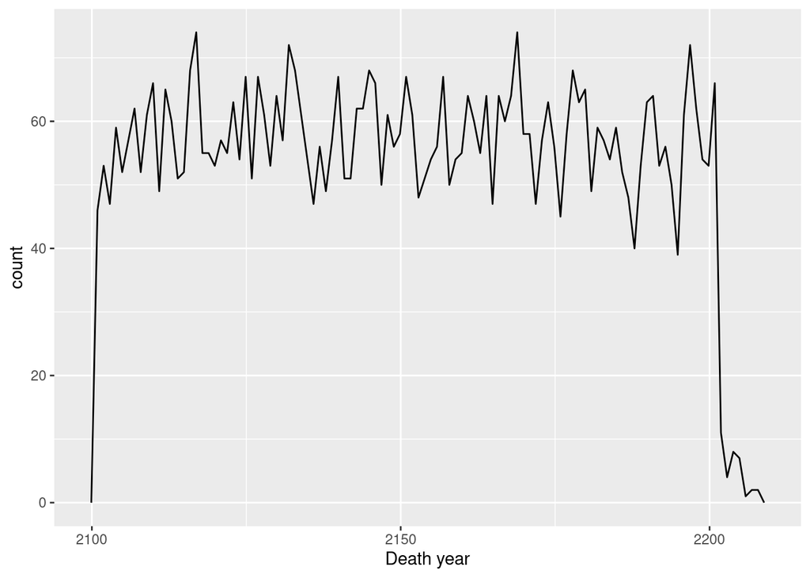

```r
    admission %>%
      filter(!is.na(DEATHTIME)) %>%
      ggplot(aes(x = DEATHTIME)) +
      geom_freqpoly(binwidth = 31536000) +
      labs(x = "Death year")
```

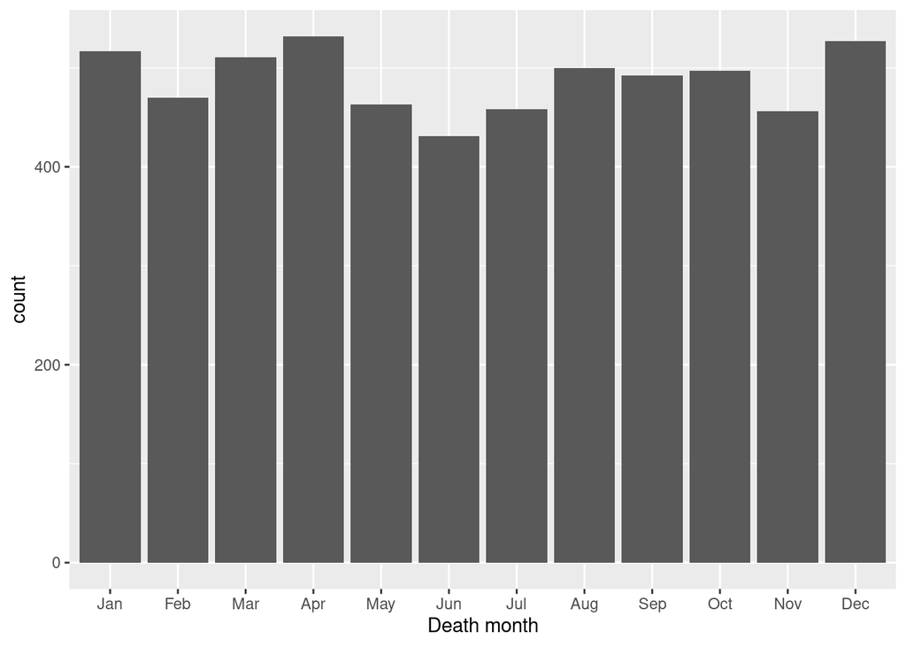

```r
    admission %>%
      filter(!is.na(DEATHTIME)) %>%
      mutate(death_month = month(DEATHTIME, label = TRUE)) %>%
      ggplot(aes(x = death_month)) +
      geom_bar() +
      labs(x = "Death month")
```

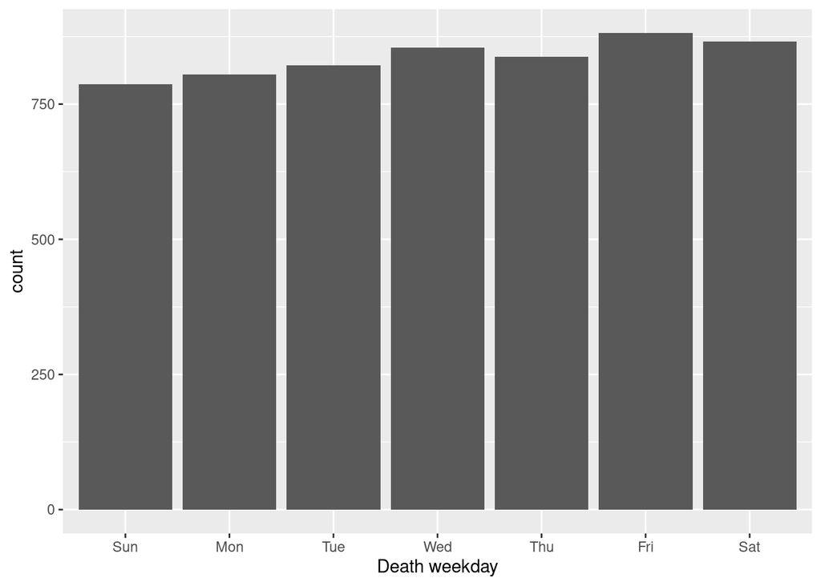

```r
    admission %>%
      filter(!is.na(DEATHTIME)) %>%
      mutate(death_wday = wday(DEATHTIME, label = TRUE)) %>%
      ggplot(aes(x = death_wday)) +
      geom_bar() +
      labs(x = "Death weekday")
```

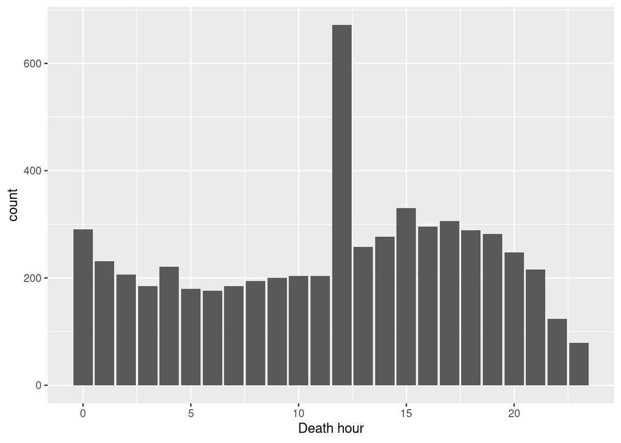

```r
    admission %>%
      filter(!is.na(DEATHTIME)) %>%
      mutate(death_hour = hour(DEATHTIME)) %>%
      ggplot(aes(x = death_hour)) +
      geom_bar() +
      labs(x = "Death hour")
```

## Q2

Link the data in `ADMISSION.csv` and `PATIENTS.csv` (https://mimic.physionet.org/mimictables/patients/) and summarize following variables using appropriate graphs:

- gender
- age at admission

**solution:**

### Import data and link the data

Let’s turn flat files into tibbles and link the tibbles. `PATIENTS.csv` contains unique patient information. Then through left joint to admission information, every admission record is linked to one patient while the patient information shows up multiple times.

```r
    admission <- read_csv("/home/203bdata/mimic-iii/ADMISSIONS.csv",
                         col_types = cols(ROW_ID = col_integer(),
                                          SUBJECT_ID = col_integer(),
                                          HADM_ID = col_integer(),
                                          HOSPITAL_EXPIRE_FLAG = col_logical(),
                                          HAS_CHARTEVENTS_DATA = col_logical()))
    patient <- read_csv("/home/203bdata/mimic-iii/PATIENTS.csv")
    adm_pinfo <- left_join(admission, patient, by = "SUBJECT_ID")
    adm_pinfo %>% print(width = Inf)
```

```
## # A tibble: 58,976 x 26
##    ROW_ID.x SUBJECT_ID HADM_ID ADMITTIME           DISCHTIME
##       <int>      <dbl>   <int> <dttm>              <dttm>
##  1       21         22  165315 2196-04-09 12:26:00 2196-04-10 15:54:00
##  2       22         23  152223 2153-09-03 07:15:00 2153-09-08 19:10:00
##  3       23         23  124321 2157-10-18 19:34:00 2157-10-25 14:00:00
##  4       24         24  161859 2139-06-06 16:14:00 2139-06-09 12:48:00
##  5       25         25  129635 2160-11-02 02:06:00 2160-11-05 14:55:00
##  6       26         26  197661 2126-05-06 15:16:00 2126-05-13 15:00:00
##  7       27         27  134931 2191-11-30 22:16:00 2191-12-03 14:45:00
##  8       28         28  162569 2177-09-01 07:15:00 2177-09-06 16:00:00
##  9       29         30  104557 2172-10-14 14:17:00 2172-10-19 14:37:00
## 10       30         31  128652 2108-08-22 23:27:00 2108-08-30 15:00:00
##    DEATHTIME           ADMISSION_TYPE ADMISSION_LOCATION
##    <dttm>              <chr>          <chr>
```

[output cut: 71 more lines]

### Graphs

#### gender

Based on each unique patient, we can get a sense of the gender distribution. The gender is treated as a discrete variable. The ratio of male patients to female patients is around 1 and the amount of male patients is larger than the amount of female patients.

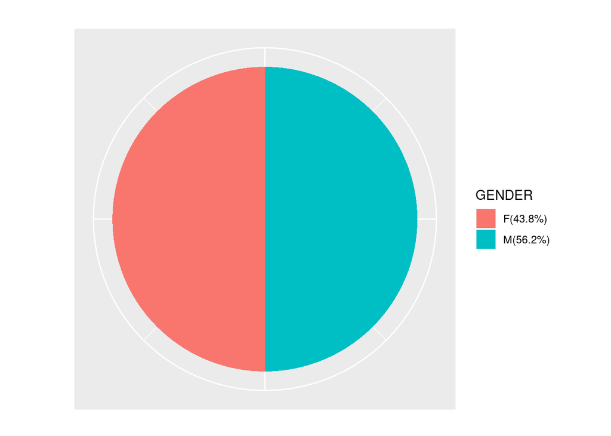

```r
    adm_gender <- distinct(adm_pinfo, SUBJECT_ID, .keep_all = TRUE) %>%
      group_by(GENDER) %>%
      summarise(
        count = n()
      ) %>% as.data.frame
    label_value <- paste('(', round(adm_gender$count / sum(adm_gender$count) *
                                      100, 1), '%)', sep = '')
    label <- paste(adm_gender$GENDER, label_value, sep = '')
    adm_gender %>%
      ggplot(mapping = aes(x = 'portion', fill = GENDER)) +
      geom_bar(width = 1) +
      coord_polar("y") +
      labs(x = '', y = '', title = '') +
      theme(axis.text = element_blank()) +
      theme(axis.ticks = element_blank()) +
      scale_fill_discrete(labels = label)
```

#### age at admission

Based on each admission record, the age at admission is treated as a continuous variable. The newborns take the largest part and people around 75 years old also take a big part.

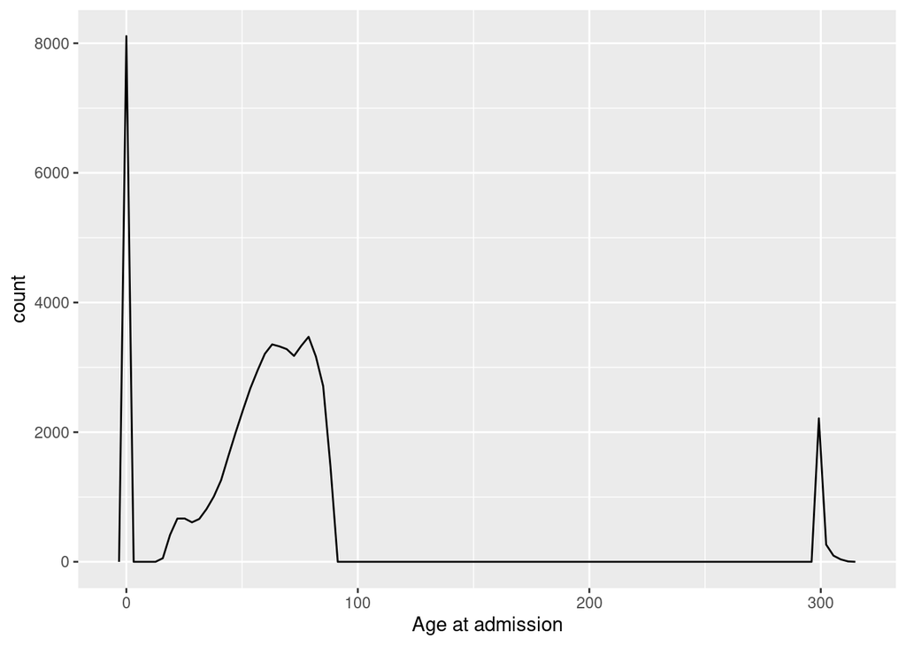

```r
    adm_pinfo %>%
      mutate(AGE = as.numeric(as.duration(ADMITTIME - DOB) / 31536000)) %>%
      ggplot(aes(x = AGE)) +
      geom_freqpoly(bins = 100) +
      labs(x = "Age at admission")
```

## Q3

`ICUSTAYS.csv` (https://mimic.physionet.org/mimictables/icustays/) contains data about Intensive Care Units (ICU) stays. Summarize following variables using appropriate graphs:

- length of ICU stay
- first ICU unit
- gender
- age

**solution:**

### Import data and link the data

Let’s turn flat files into tibbles and link the tibbles. `PATIENTS.csv` contains unique patient information. Then through left joint to ICU stay information, every ICU stay record is linked to one patient while the patient information shows up multiple times.

```r
    patient <- read_csv("/home/203bdata/mimic-iii/PATIENTS.csv")
    icustays <- read_csv("/home/203bdata/mimic-iii/ICUSTAYS.csv")
    icustay <- left_join(icustays, patient, by = "SUBJECT_ID")
    icustay %>% print(width = Inf)
```

```
## # A tibble: 61,532 x 19
##    ROW_ID.x SUBJECT_ID HADM_ID ICUSTAY_ID DBSOURCE FIRST_CAREUNIT LAST_CAREUNIT
##       <dbl>      <dbl>   <dbl>      <dbl> <chr>    <chr>          <chr>
##  1      365        268  110404     280836 carevue  MICU           MICU
##  2      366        269  106296     206613 carevue  MICU           MICU
##  3      367        270  188028     220345 carevue  CCU            CCU
##  4      368        271  173727     249196 carevue  MICU           SICU
##  5      369        272  164716     210407 carevue  CCU            CCU
##  6      370        273  158689     241507 carevue  MICU           MICU
##  7      371        274  130546     254851 carevue  MICU           MICU
##  8      372        275  129886     219649 carevue  CCU            CCU
##  9      373        276  135156     206327 carevue  CCU            CCU
## 10      374        277  171601     272866 carevue  NICU           NICU
##    FIRST_WARDID LAST_WARDID INTIME              OUTTIME               LOS
##           <dbl>       <dbl> <dttm>              <dttm>              <dbl>
```

[output cut: 35 more lines]

### Graphs

#### length of ICU stay

Based on each ICU stay record, the length of ICU stay is treated as a discrete variable. Most of the patients stay in the ICU for less than 12 days at a time.

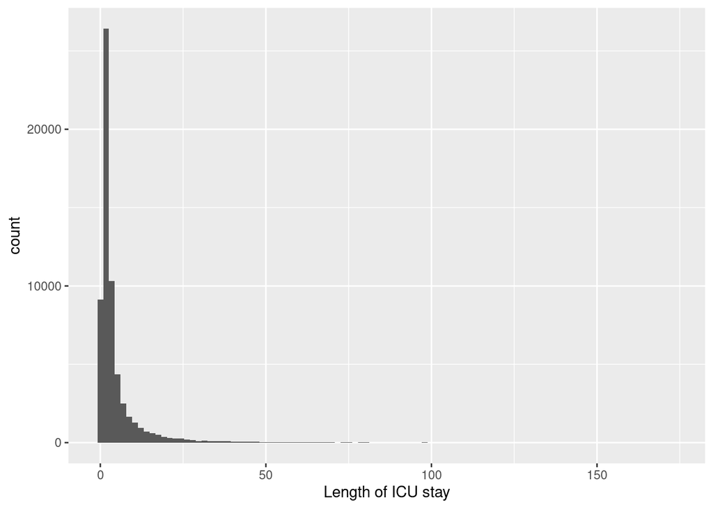

```r
    icustay %>%
      mutate(los_days = as.numeric(as.duration(OUTTIME - INTIME) / 86400)) %>%
      ggplot(aes(x = los_days)) +
      geom_histogram(bins = 100) +
      labs(x = "Length of ICU stay")
```

#### first ICU unit

Based on each ICU stay record, the first ICU unit is treated as a discrete variable. Most of the patients are admitted to MICU at the beginning.

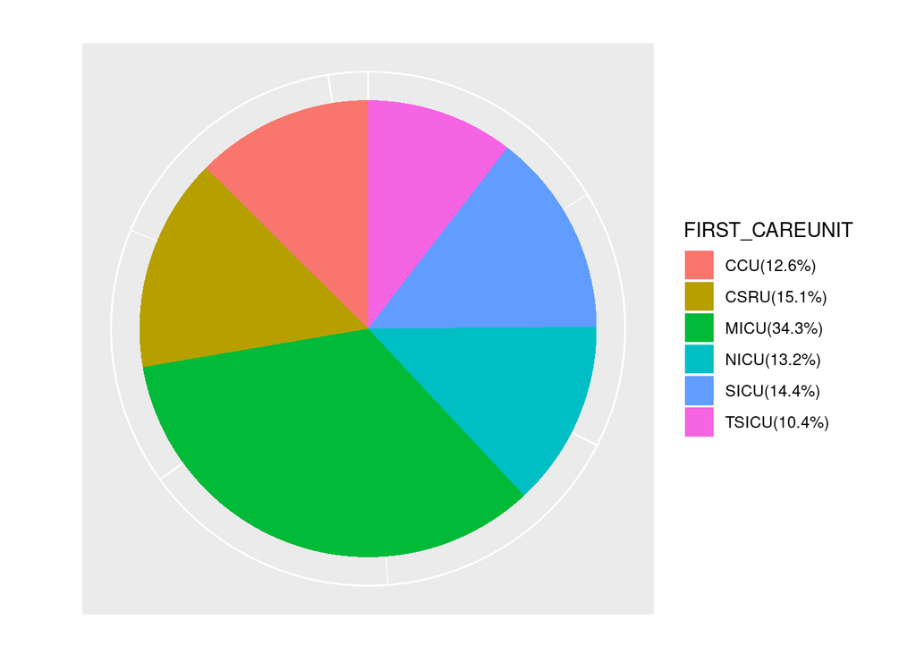

```r
    ICUunit <- icustay %>%
      group_by(FIRST_CAREUNIT) %>%
      summarise(
        count = n()
      ) %>% as.data.frame
    label_value <- paste('(', round(ICUunit$count / sum(ICUunit$count) * 100,
                                    1), '%)', sep = '')
    label <- paste(ICUunit$FIRST_CAREUNIT, label_value, sep = '')
    icustay %>%
      ggplot(mapping = aes(x = 'portion', fill = FIRST_CAREUNIT)) +
      geom_bar(width = 1) +
      coord_polar("y") +
      labs(x = '', y = '', title = '') +
      theme(axis.text = element_blank()) +
      theme(axis.ticks = element_blank()) +
      scale_fill_discrete(labels = label)
```

#### gender

Based on each unique patient, we can get a sense of the gender distribution. The gender is treated as a discrete variable. The ratio of male patients to female patients is around 1 and the amount of male patients is larger than the amount of female patients.

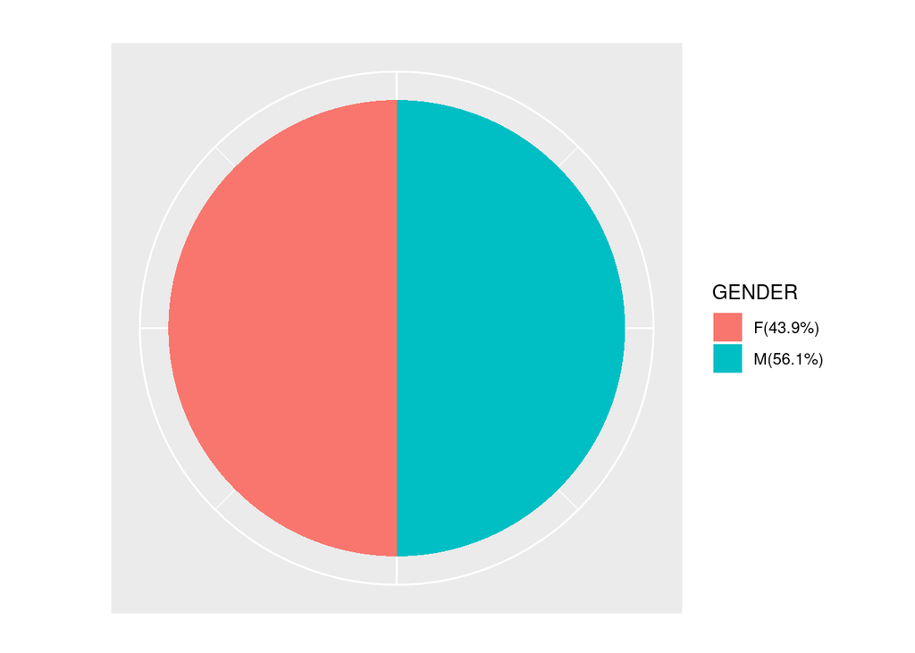

```r
    gender <- distinct(icustay, SUBJECT_ID, .keep_all = TRUE) %>%
      group_by(GENDER) %>%
      summarise(
        count = n()
      ) %>% as.data.frame
    label_value <- paste('(', round(gender$count / sum(gender$count) * 100,
                                    1), '%)', sep = '')
    label <- paste(gender$GENDER, label_value, sep = '')
    gender %>%
      ggplot(mapping = aes(x = 'portion', fill = GENDER)) +
      geom_bar(width = 1) +
      coord_polar("y") +
      labs(x = '', y = '', title = '') +
      theme(axis.text = element_blank()) +
      theme(axis.ticks = element_blank()) +
      scale_fill_discrete(labels = label)
```

#### age

Based on each unique patient, we can get a sense of the recent age distribution of the patients. The age is treated as a discrete variable. The newborns take the largest part and people around 75 years old also take a big part.

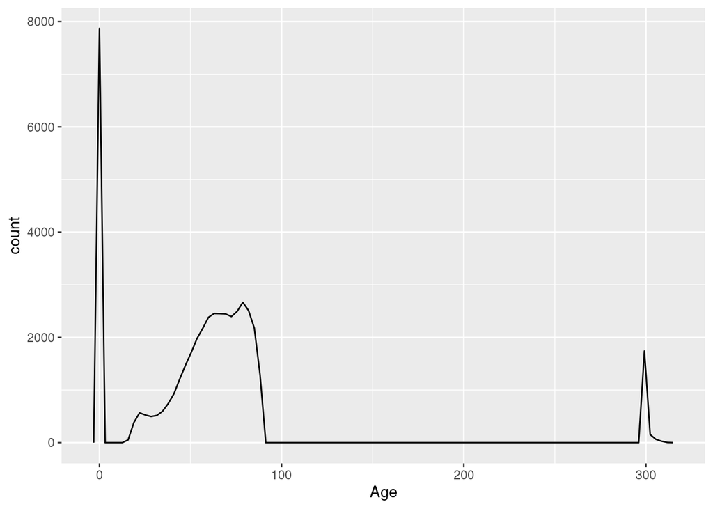

```r
    icustay %>%
      mutate(age = as.numeric(as.duration(INTIME - DOB) / 31536000)) %>%
      group_by(SUBJECT_ID) %>%
      filter(rank(desc(age)) == 1) %>%
      ggplot(aes(x = age)) +
      geom_freqpoly(bins = 100) +
      labs(x = "Age")
```

## Q4

`CHARTEVENTS.csv` (https://mimic.physionet.org/mimictables/chartevents/) contains all the charted data available for a patient. During their ICU stay, the primary repository of a patient’s information is their electronic chart. The `ITEMID` variable indicates a single measurement type in the database. The `VALUE` variable is the value measured for `ITEMID`.

`D_ITEMS.csv` (https://mimic.physionet.org/mimictables/d_items/) is the dictionary for the `ITEMID` in `CHARTEVENTS.csv`. Find potential values of `ITEMID` that correspond to systolic blood pressure, i.e., `LABEL` contains the string `systolic`.

Compile a tibble that contains the first ICU stay of unique patients, with the patient’s demographic information, the first systolic blood pressure measurement during ICU stay, and whether the patient died within 30 days of hospitcal admission.

**solution:**

### Prerequisites

Load htmlwidgets:

```r
    library(htmlwidgets)
```

### Import data

```r
    admission <- read_csv("/home/203bdata/mimic-iii/ADMISSIONS.csv",
                         col_types = cols(ROW_ID = col_integer(),
                                          SUBJECT_ID = col_integer(),
                                          HADM_ID = col_integer(),
                                          HOSPITAL_EXPIRE_FLAG = col_logical(),
                                          HAS_CHARTEVENTS_DATA = col_logical()))
    patient <- read_csv("/home/203bdata/mimic-iii/PATIENTS.csv")
    icustay <- read_csv("/home/203bdata/mimic-iii/ICUSTAYS.csv")
    chart <- read_csv("/home/203bdata/mimic-iii/CHARTEVENTS.csv")
    item <- read_csv("/home/203bdata/mimic-iii/D_ITEMS.csv")
    admission %>% print(width = Inf)
```

```
## # A tibble: 58,976 x 19
##    ROW_ID SUBJECT_ID HADM_ID ADMITTIME           DISCHTIME
##     <int>      <int>   <int> <dttm>              <dttm>
##  1     21         22  165315 2196-04-09 12:26:00 2196-04-10 15:54:00
##  2     22         23  152223 2153-09-03 07:15:00 2153-09-08 19:10:00
##  3     23         23  124321 2157-10-18 19:34:00 2157-10-25 14:00:00
##  4     24         24  161859 2139-06-06 16:14:00 2139-06-09 12:48:00
##  5     25         25  129635 2160-11-02 02:06:00 2160-11-05 14:55:00
##  6     26         26  197661 2126-05-06 15:16:00 2126-05-13 15:00:00
##  7     27         27  134931 2191-11-30 22:16:00 2191-12-03 14:45:00
##  8     28         28  162569 2177-09-01 07:15:00 2177-09-06 16:00:00
##  9     29         30  104557 2172-10-14 14:17:00 2172-10-19 14:37:00
## 10     30         31  128652 2108-08-22 23:27:00 2108-08-30 15:00:00
##    DEATHTIME           ADMISSION_TYPE ADMISSION_LOCATION
##    <dttm>              <chr>          <chr>
```

[output cut: 59 more lines]

```r
    patient %>% print(width = Inf)
```

```
## # A tibble: 46,520 x 8
##    ROW_ID SUBJECT_ID GENDER DOB                 DOD
##     <dbl>      <dbl> <chr>  <dttm>              <dttm>
##  1    234        249 F      2075-03-13 00:00:00 NA
##  2    235        250 F      2164-12-27 00:00:00 2188-11-22 00:00:00
##  3    236        251 M      2090-03-15 00:00:00 NA
##  4    237        252 M      2078-03-06 00:00:00 NA
##  5    238        253 F      2089-11-26 00:00:00 NA
##  6    239        255 M      2109-08-05 00:00:00 NA
##  7    240        256 M      2086-07-31 00:00:00 NA
##  8    241        257 F      2031-04-03 00:00:00 2121-07-08 00:00:00
##  9    242        258 F      2124-09-19 00:00:00 NA
## 10    243        260 F      2105-03-23 00:00:00 NA
##    DOD_HOSP            DOD_SSN             EXPIRE_FLAG
##    <dttm>              <dttm>                    <dbl>
##  1 NA                  NA                            0
##  2 2188-11-22 00:00:00 NA                            1
##  3 NA                  NA                            0
##  4 NA                  NA                            0
##  5 NA                  NA                            0
##  6 NA                  NA                            0
##  7 NA                  NA                            0
##  8 2121-07-08 00:00:00 2121-07-08 00:00:00           1
##  9 NA                  NA                            0
## 10 NA                  NA                            0
## # … with 46,510 more rows
```

```r
    icustay %>% print(width = Inf)
```

```
## # A tibble: 61,532 x 12
##    ROW_ID SUBJECT_ID HADM_ID ICUSTAY_ID DBSOURCE FIRST_CAREUNIT LAST_CAREUNIT
##     <dbl>      <dbl>   <dbl>      <dbl> <chr>    <chr>          <chr>
##  1    365        268  110404     280836 carevue  MICU           MICU
##  2    366        269  106296     206613 carevue  MICU           MICU
##  3    367        270  188028     220345 carevue  CCU            CCU
##  4    368        271  173727     249196 carevue  MICU           SICU
##  5    369        272  164716     210407 carevue  CCU            CCU
##  6    370        273  158689     241507 carevue  MICU           MICU
##  7    371        274  130546     254851 carevue  MICU           MICU
##  8    372        275  129886     219649 carevue  CCU            CCU
##  9    373        276  135156     206327 carevue  CCU            CCU
## 10    374        277  171601     272866 carevue  NICU           NICU
##    FIRST_WARDID LAST_WARDID INTIME              OUTTIME               LOS
##           <dbl>       <dbl> <dttm>              <dttm>              <dbl>
##  1           52          52 2198-02-14 23:27:38 2198-02-18 05:26:11 3.25
##  2           52          52 2170-11-05 11:05:29 2170-11-08 17:46:57 3.28
##  3           57          57 2128-06-24 15:05:20 2128-06-27 12:32:29 2.89
##  4           52          23 2120-08-07 23:12:42 2120-08-10 00:39:04 2.06
##  5           57          57 2186-12-25 21:08:04 2186-12-27 12:01:13 1.62
##  6           52          52 2141-04-19 06:12:05 2141-04-20 17:52:11 1.49
##  7           12          12 2114-06-28 22:28:44 2114-07-07 18:01:16 8.81
##  8            7           7 2170-10-07 11:28:53 2170-10-14 14:38:07 7.13
##  9           57          57 2147-11-20 09:02:23 2147-11-21 17:08:52 1.34
## 10           56          56 2132-10-21 21:11:46 2132-10-22 14:44:48 0.731
## # … with 61,522 more rows
```

```r
    chart %>% print(width = Inf)
```

```
## # A tibble: 1,048,575 x 15
##    ROW_ID SUBJECT_ID HADM_ID ICUSTAY_ID ITEMID CHARTTIME     STORETIME      CGID
##     <dbl>      <dbl>   <dbl>      <dbl>  <dbl> <chr>         <chr>         <dbl>
##  1    788         36  165660     241249 223834 5/12/34 12:00 5/12/34 13:56 17525
##  2    789         36  165660     241249 223835 5/12/34 12:00 5/12/34 13:56 17525
##  3    790         36  165660     241249 224328 5/12/34 12:00 5/12/34 12:18 20823
##  4    791         36  165660     241249 224329 5/12/34 12:00 5/12/34 12:19 20823
##  5    792         36  165660     241249 224330 5/12/34 12:00 5/12/34 12:19 20823
##  6    793         36  165660     241249 224331 5/12/34 12:00 5/12/34 12:19 20823
##  7    794         36  165660     241249 224332 5/12/34 12:00 5/12/34 14:44 17525
##  8    795         36  165660     241249 224663 5/12/34 12:00 5/12/34 14:44 17525
##  9    796         36  165660     241249 224665 5/12/34 12:00 5/12/34 14:44 17525
## 10    797         36  165660     241249 220224 5/12/34 12:35 5/12/34 12:38 20889
##     VALUE VALUENUM VALUEUOM WARNING ERROR RESULTSTATUS STOPPED
##     <dbl>    <dbl> <chr>      <dbl> <dbl> <lgl>        <lgl>
##  1  15       15    L/min          0     0 NA           NA
##  2 100      100    <NA>           0     0 NA           NA
##  3   0.37     0.37 <NA>           0     0 NA           NA
##  4   6        6    min            0     0 NA           NA
##  5   2.5      2.5  <NA>           0     0 NA           NA
##  6   0        0    ml/hr          0     0 NA           NA
##  7   3        3    <NA>           0     0 NA           NA
##  8   8        8    <NA>           0     0 NA           NA
##  9   1.11     1.11 <NA>           0     0 NA           NA
## 10  58       58    mmHg           1     0 NA           NA
## # … with 1,048,565 more rows
```

```r
    item %>% print(width = Inf)
```

```
## # A tibble: 12,487 x 10
##    ROW_ID ITEMID LABEL                                       ABBREVIATION
##     <dbl>  <dbl> <chr>                                       <lgl>
##  1    457    497 Patient controlled analgesia (PCA) [Inject] NA
##  2    458    498 PCA Lockout (Min)                           NA
##  3    459    499 PCA Medication                              NA
##  4    460    500 PCA Total Dose                              NA
##  5    461    501 PCV Exh Vt (Obser)                          NA
##  6   1157    927 Allergy 2                                   NA
##  7   1158    930 Ext                                         NA
##  8   1159    935 Allergy 3                                   NA
##  9   1160    938 blood cultures                              NA
## 10   1161    940 trach care                                  NA
##    DBSOURCE LINKSTO     CATEGORY UNITNAME PARAM_TYPE CONCEPTID
##    <chr>    <chr>       <chr>    <lgl>    <lgl>      <lgl>
##  1 carevue  chartevents <NA>     NA       NA         NA
##  2 carevue  chartevents <NA>     NA       NA         NA
##  3 carevue  chartevents <NA>     NA       NA         NA
##  4 carevue  chartevents <NA>     NA       NA         NA
##  5 carevue  chartevents <NA>     NA       NA         NA
##  6 carevue  chartevents <NA>     NA       NA         NA
##  7 carevue  chartevents <NA>     NA       NA         NA
##  8 carevue  chartevents <NA>     NA       NA         NA
##  9 carevue  chartevents <NA>     NA       NA         NA
## 10 carevue  chartevents <NA>     NA       NA         NA
## # … with 12,477 more rows
```

### Compile the tibble

- Select the first systolic blood pressure measurement information. First, find potential values of `ITEMID` that correspond to systolic blood pressure. Then, substract the systolic blood pressure measurement information from `CHARTEVENTS.csv` and choose the first systolic blood pressure measurement based on the `CHARTTIME` for each unique patient. Only keep the `SUBJECT_ID` and the corresponding first systolic blood pressure measurement information.

```r
    bloodp <- item %>%
      filter(str_detect(LABEL, "systolic")) %>%
      select(ITEMID, LABEL)
    bloodp2 <- inner_join(chart, bloodp, by = "ITEMID") %>%
      group_by(SUBJECT_ID) %>%
      filter(rank(CHARTTIME) == 1) %>%
      select(SUBJECT_ID, LABEL)
    bloodp2 %>% print(width = Inf)
```

```
## # A tibble: 420 x 2
## # Groups:   SUBJECT_ID [420]
##    SUBJECT_ID LABEL
##         <dbl> <chr>
##  1         23 Arterial Blood Pressure systolic
##  2         36 Non Invasive Blood Pressure systolic
##  3         34 Non Invasive Blood Pressure systolic
##  4         85 Non Invasive Blood Pressure systolic
##  5        107 Non Invasive Blood Pressure systolic
##  6        109 Non Invasive Blood Pressure systolic
##  7        124 Non Invasive Blood Pressure systolic
##  8        165 Non Invasive Blood Pressure systolic
##  9        154 Non Invasive Blood Pressure systolic
## 10        188 Non Invasive Blood Pressure systolic
## # … with 410 more rows
```

- Select the first ICU stay information of unique patients. Based on the `INTIME`, choose the first ICU stay of each unique patient from `ICUSTAYS.csv`. Only keep the `SUBJECT_ID` and the corresponding first ICU stay information.

```r
    first_icu <- icustay %>%
      group_by(SUBJECT_ID) %>%
      filter(rank(INTIME) == 1) %>%
      select(SUBJECT_ID, FIRST_CAREUNIT)
    first_icu %>% print(width = Inf)
```

```
## # A tibble: 46,476 x 2
## # Groups:   SUBJECT_ID [46,476]
##    SUBJECT_ID FIRST_CAREUNIT
##         <dbl> <chr>
##  1        268 MICU
##  2        269 MICU
##  3        270 CCU
##  4        271 MICU
##  5        272 CCU
##  6        273 MICU
##  7        274 MICU
##  8        275 CCU
##  9        276 CCU
## 10        277 NICU
## # … with 46,466 more rows
```

- Select the patient’s demographic and death information. First, through left joint patient information to admission information, every admission record is linked to one patient while the patient information shows up multiple times. Then, based on the information, whether the patient died within 30 days of hospital admission can be determined. Substract information for each unique patient. For each unique patient, once one admission record shows that the patient died within 30 days, this death information is kept. Only keep the `SUBJECT_ID` and the corresponding demographic and death information.

```r
    pinfo <- left_join(admission, patient, by = "SUBJECT_ID") %>%
      mutate(dead30 = ((as.numeric(as.duration(DEATHTIME - ADMITTIME) / 86400)
                                  ) <= 30)) %>%
      group_by(SUBJECT_ID) %>%
      filter(rank(desc(dead30)) == 1) %>%
      select(SUBJECT_ID, LANGUAGE: ETHNICITY, GENDER, DOB, dead30)
    pinfo %>% print(width = Inf)
```

```
## # A tibble: 46,480 x 8
## # Groups:   SUBJECT_ID [46,480]
##    SUBJECT_ID LANGUAGE RELIGION          MARITAL_STATUS ETHNICITY
##         <dbl> <chr>    <chr>             <chr>          <chr>
##  1         22 <NA>     UNOBTAINABLE      MARRIED        WHITE
##  2         23 <NA>     CATHOLIC          MARRIED        WHITE
##  3         24 <NA>     PROTESTANT QUAKER SINGLE         WHITE
##  4         25 <NA>     UNOBTAINABLE      MARRIED        WHITE
##  5         26 <NA>     CATHOLIC          SINGLE         UNKNOWN/NOT SPECIFIED
##  6         27 <NA>     CATHOLIC          <NA>           WHITE
##  7         28 <NA>     CATHOLIC          MARRIED        WHITE
##  8         30 <NA>     CATHOLIC          MARRIED        UNKNOWN/NOT SPECIFIED
##  9         31 <NA>     CATHOLIC          MARRIED        WHITE
## 10         32 <NA>     UNOBTAINABLE      <NA>           WHITE
##    GENDER DOB                 dead30
##    <chr>  <dttm>              <lgl>
##  1 F      2131-05-07 00:00:00 NA
##  2 M      2082-07-17 00:00:00 NA
##  3 M      2100-05-31 00:00:00 NA
##  4 M      2101-11-21 00:00:00 NA
##  5 M      2054-05-04 00:00:00 NA
##  6 F      2191-11-30 00:00:00 NA
##  7 M      2103-04-15 00:00:00 NA
##  8 M      1872-10-14 00:00:00 NA
##  9 M      2036-05-17 00:00:00 TRUE
## 10 M      2124-09-29 00:00:00 NA
## # … with 46,470 more rows
```

- Compile the tibble. Full join all the information kept above by `SUBJECT_ID`. Then we get a tibble that contains the first ICU stay of unique patients, with the patient’s demographic information, the first systolic blood pressure measurement during ICU stay, and whether the patient died within 30 days of hospitcal admission.

```r
    info <- pinfo %>%
      full_join(bloodp2, by = "SUBJECT_ID") %>%
      full_join(first_icu, by = "SUBJECT_ID")
    info %>% print(width = Inf)
```

```
## # A tibble: 46,520 x 10
## # Groups:   SUBJECT_ID [46,520]
##    SUBJECT_ID LANGUAGE RELIGION          MARITAL_STATUS ETHNICITY
##         <dbl> <chr>    <chr>             <chr>          <chr>
##  1         22 <NA>     UNOBTAINABLE      MARRIED        WHITE
##  2         23 <NA>     CATHOLIC          MARRIED        WHITE
##  3         24 <NA>     PROTESTANT QUAKER SINGLE         WHITE
##  4         25 <NA>     UNOBTAINABLE      MARRIED        WHITE
##  5         26 <NA>     CATHOLIC          SINGLE         UNKNOWN/NOT SPECIFIED
##  6         27 <NA>     CATHOLIC          <NA>           WHITE
##  7         28 <NA>     CATHOLIC          MARRIED        WHITE
##  8         30 <NA>     CATHOLIC          MARRIED        UNKNOWN/NOT SPECIFIED
##  9         31 <NA>     CATHOLIC          MARRIED        WHITE
## 10         32 <NA>     UNOBTAINABLE      <NA>           WHITE
##    GENDER DOB                 dead30 LABEL
```

[output cut: 24 more lines]